# Tables and Circle Plots comparing Naive and DRTMLE group differences

MB Nebel

2021-12-01

```r
library(tidyverse)
#for tableby
library(arsenal)
library(xtable)
library(readxl)
library(circlize)
library(png)
#to remove background from .pngs
library(colordistance)
library(magick)
```

#### Define Circle plot functions:

Based on https://drmowinckels.io/blog/2018-05-25-circluar-plots-in-r-and-adding-images/ and adapted by D Lidstone & B Risk

```r
#### Function to Make Transparent Colors
t_col <- function(color, percent = 50, name = NULL) {
  #      color = color name
  #    percent = % transparency
  #       name = an optional name for the color

  ## Get RGB values for named color
  rgb.val <- col2rgb(color)

  ## Make new color using input color as base and alpha set by transparency
  t.col <- rgb(rgb.val[1], rgb.val[2], rgb.val[3],
               max = 255,
               alpha = (100 - percent) * 255 / 100,
               names = name)

  ## Save the color
  invisible(t.col)
}

# varname: a variable name corresponding to a column of results.ave
# thresh: threshold to use for displaying chords

myChordDiagram = function(data,varname,alpha=0.20,alphaname,title) {
  # alpha: pvalue threshold
  # alphaname: column of data with pvalues

  #

  ## Set transparent color, used to mask unwanted chords
  trcol <- t_col("white", perc = 100, name = "white")

  ## Set colors for negative and positive values
  poscol <- t_col("DodgerBlue4", perc = 15, name = "lt.blue") #positive correlation color
  negcol <- t_col("red", perc = 15, name = "lt.red") #negative correlation color

  ## Set names for networks (netLab)
  icInfo <- read_excel("componentLabels_pca85_ica30.xlsx")
  netLab <-icInfo$cognitive.domain[icInfo$signal==1]

  DATA = data.frame(images = list.files("ic_pngs_noBG",full.names = T), stringsAsFactors = F) %>%
    mutate(
      names = gsub("[a-zA-Z]|[[:punct:]]","", images),
      values = sample(0:100, size=nrow(.), replace = T)
    )
  head(DATA)

  # Assign group in the original data frame
  DATA$Group = netLab %>% as.factor()

  nGroups = length(unique(DATA$Group))

  #### arrange circle plot by group
  oDATA = DATA %>% arrange(Group)

  #### trying to avoid track text changing direction within a network
  oDATA$NewOrder = rep(NA, nrow(oDATA))
  oDATA$NewOrder[oDATA$Group=="Attn"]=7
  oDATA$NewOrder[oDATA$Group=="Control"]=1
  oDATA$NewOrder[oDATA$Group=="SalVenAtt"]=3
  oDATA$NewOrder[oDATA$Group=="CB"]=4
  oDATA$NewOrder[oDATA$Group=="Default"]=2
  oDATA$NewOrder[oDATA$Group=="SomMot"]=5
  oDATA$NewOrder[oDATA$Group=="Vis"]=6

  oDATA = oDATA %>% arrange(NewOrder)

   # Get colours, turn the vector into characters, and then use the factor numbers of DATA$NewOrder to assign colour.

  #cColors = wesanderson::wes_palette("FantasticFox1", nGroups, type = 'continuous')
  cColors = viridis::plasma(nGroups)

  oDATA$gColor = cColors[1:nGroups] %>% as.character %>%
    .[as.numeric(oDATA$NewOrder)]

  #### Define small gap between ICs and big gap between networks
  # sectorGap[1] is the gap after the first sector
  # sectorGap[end] should be bigGap

  smallGap = 1
  bigGap = 7
  sectorGap = rep(bigGap, nrow(DATA))

  for (ig in 1:nrow(oDATA)-1){
    sectorGap[ig] = ifelse(oDATA$NewOrder[ig+1]==oDATA$NewOrder[ig], smallGap, bigGap)
  }

  ############################################
  # Create the weighted adjacency matrix:

  # Construct the "from" edge:
  ic.from =   substr(data$EdgeName,1,2)
  ic.from = ifelse(substr(ic.from,2,2)=='-',paste0('0',substr(ic.from,1,1)),ic.from)
  # visually check it looks good:
  cbind(data$EdgeName,ic.from)

  # Construct the "to" edge
  ic.to = substr(data$EdgeName,nchar(data$EdgeName)-1,nchar(data$EdgeName))
  ic.to = ifelse(substr(ic.to,1,1)=='-',paste0('0',substr(ic.to,2,2)),ic.to)
  # visually check it looks good:
  cbind(data$EdgeName,ic.to)

  # modify the THIRD variable to create chords for different variables:
  PAIRS = data.frame(ic.from,ic.to,data[,varname])

  #### Index specific pairs by a threshold

  neg_ix = data[,alphaname] < alpha & PAIRS[,3]<0
  pos_ix = data[,alphaname] < alpha & PAIRS[,3]>0

  cols = rep(trcol,nrow(PAIRS))
  cols[neg_ix]=negcol
  cols[pos_ix]=poscol

  ## Set plot background to white
  par(bg = 'white')

  ##
  circos.par(gap.after = sectorGap)

  ##plot updated Chord diagram with new colors
  myPlot = chordDiagram(PAIRS, annotationTrack = c("grid"),
                        annotationTrackHeight=c(0.05, 0.01),
                        preAllocateTracks = list(track.height = 0.32),
                        order=oDATA$names, grid.col = setNames(oDATA$gColor, oDATA$names), col=cols)
  title(title,col.main="black",cex.main=1.5)

  as_radians = function(x) x*pi/180

  ## Loop through images and plot brain maps
  u=0
  for(si in get.all.sector.index()){
    xplot=get.cell.meta.data("xplot",si)
    u=u+1

    # Small workaround because coordinate 0 should be 360
    if(xplot[1] == 0) xplot[1] = 360


    x=.86*cos(as_radians((xplot[2]+xplot[1])/2))
    y=.86*sin(as_radians((xplot[2]+xplot[1])/2))

    oDATA$images[grep(si, oDATA$images)] %>%
      readPNG() %>%
      rasterImage(x-0.09, y-0.09, x+0.09, y+0.09)
  }

  #### set labels to be black
  circos.track(track.index = 1, panel.fun = function(x, y) {
    xlim = get.cell.meta.data("xlim")
    xplot = get.cell.meta.data("xplot")
    ylim = get.cell.meta.data("ylim")
    sector.name = get.cell.meta.data("sector.index")

    circos.text(mean(xlim), ylim[1], sector.name, facing = "inside",
                niceFacing = TRUE, adj = c(0.5, 0), col= "black")
  }, bg.border = NA)

  #    myPlot
}
```

#### Load results from two sets of 200 seeds

```r
results.all=NULL
for (i in 1:200) {
  load(paste0('../Results/Results_20November2021/ic30_pc85_glm_gam_drtmle_seed',i,'.RData'))
  results.all = rbind(results.all,results.df)
}
rm(results.df)

# second set of seeds:
results.all2=NULL
for (i in 201:400) {
  load(paste0('../Results/Results_20November2021/ic30_pc85_glm_gam_drtmle_seed',i,'.RData'))
  results.all2 = rbind(results.all2,results.df)
}
rm(results.df)
```

#### Average results from all seeds

```r
#SL = superlearner

results.ave = rbind(results.all,results.all2) %>%
  group_by(EdgeName) %>%
  summarize(mean.ASD.naive=round(mean(mean.ASD.naive), digits = 3),
            mean.TD.naive=round(mean(mean.TD.naive), digits = 3),
            mean.diff.naive=mean(mean.diff.naive),
            z.stat.ASD.naive=mean(z.stat.ASD.naive),
            z.stat.TD.naive=mean(z.stat.TD.naive),
            z.stat.diff.naive=round(mean(z.stat.diff.naive), digits = 3),
            mean.ASD.SL=round(mean(mean.ASD.SL), digits = 3),
            mean.TD.SL=round(mean(mean.TD.SL), digits = 3),
            mean.diff.SL=round(mean(mean.diff.SL), digits = 3),
            z.stat.ASD.SL=mean(z.stat.ASD.SL),
            z.stat.TD.SL=mean(z.stat.TD.SL),
            z.stat.diff.SL=round(mean(z.stat.diff.SL), digits = 2))
```

#### Add network names

```r
icInfo <- read_excel("componentLabels_pca85_ica30.xlsx")

results.ave <- results.ave %>%
  mutate(EdgeName = gsub("r.|ic", "", EdgeName)) %>%
  mutate(EdgeName = gsub("[.]", "-", EdgeName)) %>%
  mutate(ic.from = gsub("[-]", "", substr(EdgeName, 1, 2))) %>%
  mutate(ic.to = gsub("[-]", "", substr(EdgeName, nchar(EdgeName)-1,nchar(EdgeName)))) %>%
  mutate(net1 = icInfo$cognitive.domain[as.numeric(ic.from)]) %>%
  mutate(net2 = icInfo$cognitive.domain[as.numeric(ic.to)])
```

#### Calculate uncorrected p values for both methods and plot histograms

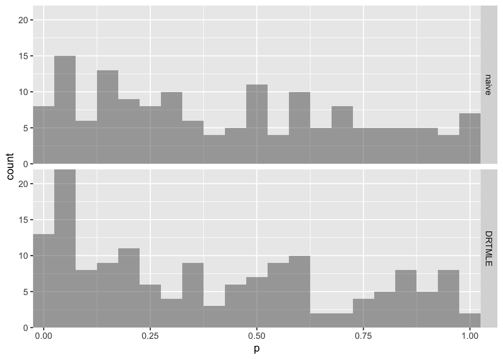

```r
#calculate p values
results.ave$p.naive = 2*(1-pnorm(abs(results.ave$z.stat.diff.naive)))
results.ave$p.SL = 2*(1-pnorm(abs(results.ave$z.stat.diff.SL)))

pVariables = c("EdgeName", "p.naive", "p.SL")

pvalues <- reshape2::melt(results.ave[, pVariables],
                         id.vars="EdgeName",
                         variable.name = "method",
                         value.name = "p")

method.labs <- c("naive", "DRTMLE")
names(method.labs) <- c("p.naive", "p.SL")

ggplot(pvalues, aes(x=p))+
  geom_histogram(position = "identity", alpha=0.5, inherit.aes=TRUE, binwidth = .05)+
  scale_x_continuous(expand = c(0, 0))+
  scale_y_continuous(expand = c(0, 0))+
  facet_grid(method~., labeller = labeller(method = method.labs))
```

#### FDR-adjusted p values

```r
results.ave$p.naive.fdr = round(p.adjust(results.ave$p.naive,method='BH'), digits = 3)
results.ave$p.SL.fdr = round(p.adjust(results.ave$p.SL,method='BH'), digits = 3)
```

#### Determine edges showing a significant group difference FDR=.05

```r
fdr05.edges.SL = which(results.ave$p.SL.fdr<.05)
fdr05.edges.naive = which(results.ave$p.naive.fdr<.05)

all(fdr05.edges.naive %in% fdr05.edges.SL)
```

```
## [1] TRUE
```

All edges indicated by naive approach are also indicated by DRTMLE at the FDR=0.05 level

#### Summary of network pairs showing a significant group difference using DRTMLE, FDR=.05

```r
tabfdr05<- tableby(net1 ~ net2,
                 data=filter(results.ave , p.SL.fdr<.05))
summary(tabfdr05,
        title='Network pairs showing a group difference using DRTMLE FDR=.05',digits=1, digits.p=4,digits.pct=1, numeric.simplify=TRUE, total=TRUE, test=FALSE)
```

Network pairs showing a group difference using DRTMLE FDR=.05

|  | CB (N=1) | Vis (N=1) | Total (N=2) |
| --- | --- | --- | --- |
| **net2** |  |  |  |
| Attn | 1 (100.0%) | 0 (0.0%) | 1 (50.0%) |
| Control | 0 (0.0%) | 1 (100.0%) | 1 (50.0%) |

#### Remove background from .pngs of IC maps

```r
#create directory to save pngs with transparent background
dir.create("./ic_pngs_noBG")
```

```r
DATA = data.frame(images = list.files("ic_pngs",full.names = T), stringsAsFactors = F) %>%
    mutate(
      names = gsub("[a-zA-Z]|[[:punct:]]","", images),
      values = sample(0:100, size=nrow(.), replace = T)
    )
  head(DATA)
```

```
##             images names values
## 1 ic_pngs/ic01.png    01     53
## 2 ic_pngs/ic02.png    02     77
## 3 ic_pngs/ic04.png    04     13
## 4 ic_pngs/ic08.png    08     86
## 5 ic_pngs/ic13.png    13     38
## 6 ic_pngs/ic14.png    14     37
```

```r
for(iimg in seq(1:nrow(DATA))) {
 img_data <- magick::image_read(DATA$images[iimg])
 new_img <- magick::image_transparent(img_data, 'black')
 fname <- sub('ic_pngs', 'ic_pngs_noBG', DATA$images[iimg])
 magick::image_write(new_img, fname)
}
```

#### Naive ASD-TD Z-Statistic FDR=0.05

```r
png("Application_Figures/Naive_zstat_groupdifference_fdr05.png",width=5,height=5,units="in",res=200)

myChordDiagram(data=results.ave,varname='z.stat.diff.naive',alpha=0.05,alphaname='p.naive.fdr', title='')
dev.off()
```

```r
circos.clear()
```

#### DRTMLE ASD-TD Z-Statistic FDR=0.05

```r
png("Application_Figures/DRTMLE_zstat_groupdifference_fdr05.png",width=5,height=5,units="in",res=200)
myChordDiagram(data=results.ave,varname='z.stat.diff.SL',alpha=0.05,alphaname='p.SL.fdr',title='')
dev.off()
```

```r
circos.clear()
```

#### Print a and b together for report

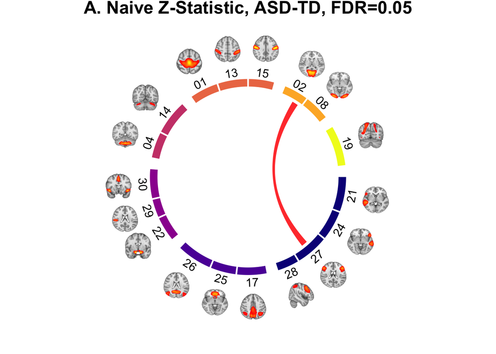

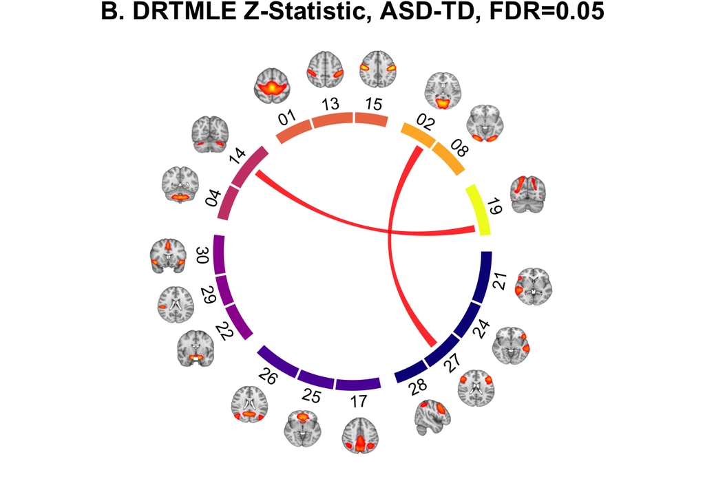

#### Determine edges showing a significant group difference FDR=.20

```r
fdr20.edges.SL = which(results.ave$p.SL.fdr<.20)
fdr20.edges.naive = which(results.ave$p.naive.fdr<.20)

all(fdr20.edges.naive %in% fdr20.edges.SL)
```

```
## [1] TRUE
```

All edges indicated by naive approach are also indicated by DRTMLE at the FDR=0.2 level

#### Summary of network pairs showing a significant group difference using the naive approach, FDR=.2

```r
tabfdr2n<- tableby(net1 ~ net2,
                 data=filter(results.ave , p.naive.fdr<.2))
summary(tabfdr2n,
        title='Network pairs showing a group difference using the naive approach, FDR=.2',digits=1, digits.p=4,digits.pct=1, numeric.simplify=TRUE, total=TRUE, test=FALSE)
```

Network pairs showing a group difference using the naive approach, FDR=.2

|  | Attn (N=1) | CB (N=3) | SomMot (N=1) | Vis (N=1) | Total (N=6) |
| --- | --- | --- | --- | --- | --- |
| **net2** |  |  |  |  |  |
| Attn | 0 (0.0%) | 1 (33.3%) | 0 (0.0%) | 0 (0.0%) | 1 (16.7%) |
| Control | 0 (0.0%) | 1 (33.3%) | 0 (0.0%) | 1 (100.0%) | 2 (33.3%) |
| Default | 1 (100.0%) | 1 (33.3%) | 1 (100.0%) | 0 (0.0%) | 3 (50.0%) |

#### Summary of network pairs showing a significant group difference using DRTMLE, FDR=.2

```r
tabfdr2<- tableby(net1 ~ net2,
                 data=filter(results.ave , p.SL.fdr<.2))
summary(tabfdr2,
        title='Network pairs showing a group difference using DRTMLE, FDR=.2',digits=1, digits.p=4,digits.pct=1, numeric.simplify=TRUE, total=TRUE, test=FALSE)
```

Network pairs showing a group difference using DRTMLE, FDR=.2

|  | Attn (N=2) | CB (N=3) | Default (N=2) | SomMot (N=2) | Vis (N=2) | Total (N=11) |
| --- | --- | --- | --- | --- | --- | --- |
| **net2** |  |  |  |  |  |  |
| Attn | 0 (0.0%) | 1 (33.3%) | 0 (0.0%) | 0 (0.0%) | 0 (0.0%) | 1 (9.1%) |
| Control | 0 (0.0%) | 1 (33.3%) | 2 (100.0%) | 1 (50.0%) | 1 (50.0%) | 5 (45.5%) |
| Default | 2 (100.0%) | 1 (33.3%) | 0 (0.0%) | 1 (50.0%) | 0 (0.0%) | 4 (36.4%) |
| SalVenAtt | 0 (0.0%) | 0 (0.0%) | 0 (0.0%) | 0 (0.0%) | 1 (50.0%) | 1 (9.1%) |

#### Create table displaying group Z-statistics from DRTMLE for edges showing a group difference at FDR=.20

```r
# group means for edges showing a group difference using DRTMLE:
results.ave$NetworkPair <- stringr::str_c(results.ave$net1, '-', results.ave$net2)

results.sigEdges = results.ave[fdr20.edges.SL,c(1, 22, 2:3, 7:9,13, 20:21)]

results.sigEdges <- results.sigEdges[order(results.sigEdges$p.naive.fdr), ]

knitr::kable(results.sigEdges, format="markdown",
             col.names = c("Edge", "Network Pair", "naive ASD mean", "naive TD mean",
                           "naive ASD-TD Z",
                           "DRTMLE ASD mean", "DRTMLE TD mean",
                           "DRTMLE ASD-TD Z",
                           "naive FDR-adjusted p",
                           "DRTMLE FDR-adjusted p"))
```

| Edge | Network Pair | naive ASD mean | naive TD mean | naive ASD-TD Z | DRTMLE ASD mean | DRTMLE TD mean | DRTMLE ASD-TD Z | naive FDR-adjusted p | DRTMLE FDR-adjusted p |
| --- | --- | --- | --- | --- | --- | --- | --- | --- | --- |
| 2-27 | Vis-Control | -0.038 | -0.024 | -4.034 | -0.038 | -0.024 | -4.20 | 0.008 | 0.004 |
| 14-19 | CB-Attn | 0.069 | 0.078 | -3.368 | 0.068 | 0.078 | -3.59 | 0.058 | 0.025 |
| 19-25 | Attn-Default | -0.085 | -0.094 | 3.026 | -0.086 | -0.094 | 2.55 | 0.126 | 0.183 |
| 13-26 | SomMot-Default | -0.031 | -0.040 | 2.799 | -0.030 | -0.039 | 3.21 | 0.139 | 0.068 |
| 14-21 | CB-Control | 0.044 | 0.053 | -2.871 | 0.043 | 0.053 | -2.93 | 0.139 | 0.086 |
| 4-17 | CB-Default | -0.067 | -0.076 | 2.779 | -0.067 | -0.076 | 3.11 | 0.139 | 0.070 |
| 19-26 | Attn-Default | 0.036 | 0.027 | 2.535 | 0.036 | 0.028 | 2.47 | 0.228 | 0.193 |
| 1-21 | SomMot-Control | 0.004 | -0.003 | 2.217 | 0.006 | -0.003 | 3.05 | 0.432 | 0.070 |
| 17-24 | Default-Control | -0.003 | 0.003 | -2.069 | -0.004 | 0.003 | -2.63 | 0.432 | 0.183 |
| 8-22 | Vis-SalVenAtt | 0.019 | 0.024 | -2.092 | 0.018 | 0.025 | -2.55 | 0.432 | 0.183 |
| 17-27 | Default-Control | 0.035 | 0.028 | 1.866 | 0.036 | 0.028 | 2.46 | 0.452 | 0.193 |

DRTMLE indicates a significant deconfounded group difference for the first **2** edges at the FDR=.05 level and an additional **9** edges at the FDR=.20 level.

Mean functional connectivity group estimates further from zero reflect stronger functional connectivity regardless of sign; positive scores reflect positive partial correlations, or more integrated intrinsic activity between independent components (ICs). Negative scores reflect negative partial correlations, or more segregated intrinsic activity between ICs.

#### Create version for paper

```r
#tab <- knitr::kable(results.sigEdges, format="latex", linesep = '')
#print(tab, type="latex")

knitr::kable(results.sigEdges, "latex", linesep = "", vline = "",
             col.names = c("Edge", "Network Pair", "naive ASD mean", "naive TD mean",
                           "naive ASD-TD Z",
                           "DRTMLE ASD mean", "DRTMLE TD mean",
                           "DRTMLE ASD-TD Z",
                           "naive FDR-adjusted p",
                           "DRTMLE FDR-adjusted p")) %>%
  #kableExtra::column_spec(9:10, width = "1 cm") %>%
  kableExtra::kable_styling(latex_options = c("scale_down")) %>%
  kableExtra::as_image(width = 7, file = "Application_Figures/tableS3.pdf")
```

#### Naive ASD-TD Z-Statistic FDR=0.20

```r
png("Application_Figures/Naive_zstat_groupdifference_fdr20.png",width=5,height=5,units="in",res=200)
myChordDiagram(data=results.ave,varname='z.stat.diff.naive',alpha=0.20,alphaname='p.naive.fdr', title='')
dev.off()
```

```r
circos.clear()
```

#### DRTMLE ASD-TD Z-Statistic FDR=0.20

```r
png("Application_Figures/DRTMLE_zstat_groupdifference_fdr20.png",width=5,height=5,units="in",res=200)
#myChordDiagram(data=results.ave,varname='z.stat.diff.SL',alpha=0.20,alphaname='p.SL.fdr',title='B. DRTMLE Z-Statistic, ASD-TD')
myChordDiagram(data=results.ave,varname='z.stat.diff.SL',alpha=0.20,alphaname='p.SL.fdr',title='')
dev.off()
```

```r
circos.clear()
```

#### Print a and b together for .html

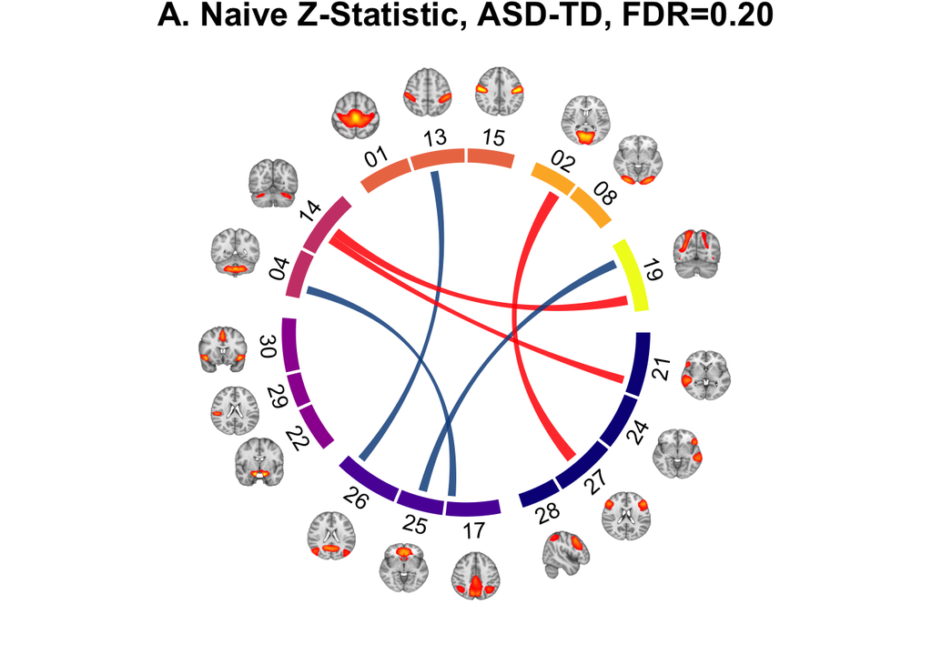

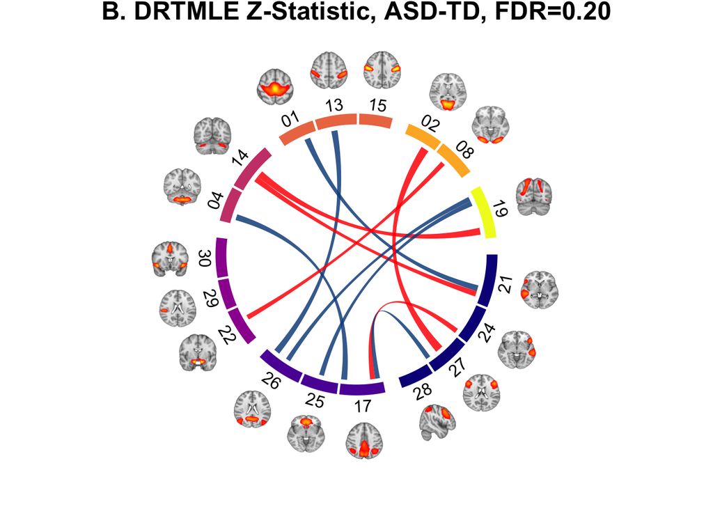

**Figure 5. The DRTMLE deconfounded group difference revealed more extensive differences than the naïve approach.** Z-statistics for autism spectrum disorder (ASD) versus typically developing (TD) using a) the na"ive test and b) using DRTMLE. Connections are thresholded using a false discovery rate (FDR) of 0.20. Blue lines indicate ASD>TD (3 in naive, 6 in DRTMLE). Red lines indicate ASD<TD (3 in naive, 5 in DRTMLE). Brain regions contributing to each independent component are illustrated and components are grouped by functional assignment. Navy nodes: control. Blue violet: default mode. Purple: salience/ventral attention. Magenta: pontomedullary/cerebellar. Coral: somatomotor. Orange: visual. Yellow: dorsal attention.